# Part I - Ford GoBike Data Exploration

## Introduction

- This analysis focuses on a Ford GoBike data set provided by Udacity, which includes information about individual rides made in a bike-sharing system covering the greater San Francisco Bay Area.

## Preliminary Wrangling

```python
# import all packages and set plots to be embedded inline
import numpy as np
import pandas as pd
import matplotlib.pyplot as plt
import seaborn as sns
import datetime as dt
from datetime import date

%matplotlib inline
sns.set_style('white')
```

```python
# load dataframe
df = pd.read_csv('201902-fordgobike-tripdata.csv')
```

```python
# view dataframe shape
df.shape
```

```
(183412, 16)
```

```python
# view dataframe data types and nulls
df.info()
```

```
<class 'pandas.core.frame.DataFrame'>
RangeIndex: 183412 entries, 0 to 183411
Data columns (total 16 columns):
 #   Column                   Non-Null Count   Dtype
---  ------                   --------------   -----
 0   duration_sec             183412 non-null  int64
 1   start_time               183412 non-null  object
 2   end_time                 183412 non-null  object
 3   start_station_id         183215 non-null  float64
 4   start_station_name       183215 non-null  object
 5   start_station_latitude   183412 non-null  float64
 6   start_station_longitude  183412 non-null  float64
 7   end_station_id           183215 non-null  float64
 8   end_station_name         183215 non-null  object
 9   end_station_latitude     183412 non-null  float64
 10  end_station_longitude    183412 non-null  float64
 11  bike_id                  183412 non-null  int64
 12  user_type                183412 non-null  object
 13  member_birth_year        175147 non-null  float64
 14  member_gender            175147 non-null  object
 15  bike_share_for_all_trip  183412 non-null  object
dtypes: float64(7), int64(2), object(7)
memory usage: 22.4+ MB
```

```python
df.head()
```

|  | duration_sec | start_time | end_time | start_station_id | start_station_name | start_station_latitude | start_station_longitude | end_station_id | end_station_name | end_station_latitude | end_station_longitude | bike_id | user_type | member_birth_year | member_gender | bike_share_for_all_trip |
| --- | --- | --- | --- | --- | --- | --- | --- | --- | --- | --- | --- | --- | --- | --- | --- | --- |
| 0 | 52185 | 2019-02-28 17:32:10.1450 | 2019-03-01 08:01:55.9750 | 21.0 | Montgomery St BART Station (Market St at 2nd St) | 37.789625 | -122.400811 | 13.0 | Commercial St at Montgomery St | 37.794231 | -122.402923 | 4902 | Customer | 1984.0 | Male | No |
| 1 | 42521 | 2019-02-28 18:53:21.7890 | 2019-03-01 06:42:03.0560 | 23.0 | The Embarcadero at Steuart St | 37.791464 | -122.391034 | 81.0 | Berry St at 4th St | 37.775880 | -122.393170 | 2535 | Customer | NaN | NaN | No |
| 2 | 61854 | 2019-02-28 12:13:13.2180 | 2019-03-01 05:24:08.1460 | 86.0 | Market St at Dolores St | 37.769305 | -122.426826 | 3.0 | Powell St BART Station (Market St at 4th St) | 37.786375 | -122.404904 | 5905 | Customer | 1972.0 | Male | No |
| 3 | 36490 | 2019-02-28 17:54:26.0100 | 2019-03-01 04:02:36.8420 | 375.0 | Grove St at Masonic Ave | 37.774836 | -122.446546 | 70.0 | Central Ave at Fell St | 37.773311 | -122.444293 | 6638 | Subscriber | 1989.0 | Other | No |
| 4 | 1585 | 2019-02-28 23:54:18.5490 | 2019-03-01 00:20:44.0740 | 7.0 | Frank H Ogawa Plaza | 37.804562 | -122.271738 | 222.0 | 10th Ave at E 15th St | 37.792714 | -122.248780 | 4898 | Subscriber | 1974.0 | Male | Yes |

```python
df.user_type.value_counts()
```

```
Subscriber    163544
Customer       19868
Name: user_type, dtype: int64
```

```python
df.bike_share_for_all_trip.value_counts()
```

```
No     166053
Yes     17359
Name: bike_share_for_all_trip, dtype: int64
```

```python
# checking the object datatype for the start/end time columns
print("start time type:", type(df.start_time[0]))
print("end time type:", type(df.end_time[0]))
```

```
start time type: <class 'str'>
end time type: <class 'str'>
```

```python
# convert start time and end time columns to datetime object
df.start_time = pd.to_datetime(df.start_time)
df.end_time = pd.to_datetime(df.end_time)

# checking the object datatype for the start/end time columns
print("start time type:", type(df.start_time[0]))
print("end time type:", type(df.end_time[0]))
```

```
start time type: <class 'pandas._libs.tslibs.timestamps.Timestamp'>
end time type: <class 'pandas._libs.tslibs.timestamps.Timestamp'>
```

```python
df.member_gender.value_counts()
```

```
Male      130651
Female     40844
Other       3652
Name: member_gender, dtype: int64
```

```python
# converting the NaN gender value to Not Given
df.member_gender.replace(np.nan, "Not Given", inplace=True)
df.member_gender.value_counts()
```

```
Male         130651
Female        40844
Not Given      8265
Other          3652
Name: member_gender, dtype: int64
```

```python
# converting member_birth_year float values to int
# replace the NaN values with zero
df.member_birth_year.replace(np.nan, float(0), inplace=True)
df.member_birth_year = df.member_birth_year.astype(int)
# replace member_birth_year zero values with None
df.member_birth_year.replace(0, None, inplace=True)
df.info()
```

```
<class 'pandas.core.frame.DataFrame'>
RangeIndex: 183412 entries, 0 to 183411
Data columns (total 16 columns):
 #   Column                   Non-Null Count   Dtype
---  ------                   --------------   -----
 0   duration_sec             183412 non-null  int64
 1   start_time               183412 non-null  datetime64[ns]
 2   end_time                 183412 non-null  datetime64[ns]
 3   start_station_id         183215 non-null  float64
 4   start_station_name       183215 non-null  object
 5   start_station_latitude   183412 non-null  float64
 6   start_station_longitude  183412 non-null  float64
 7   end_station_id           183215 non-null  float64
 8   end_station_name         183215 non-null  object
 9   end_station_latitude     183412 non-null  float64
 10  end_station_longitude    183412 non-null  float64
 11  bike_id                  183412 non-null  int64
 12  user_type                183412 non-null  object
 13  member_birth_year        183412 non-null  int64
 14  member_gender            183412 non-null  object
 15  bike_share_for_all_trip  183412 non-null  object
dtypes: datetime64[ns](2), float64(6), int64(3), object(5)
memory usage: 22.4+ MB
```

```python
df.member_birth_year.value_counts()
```

```
1988    10709
1993     9768
1989     9397
1990     9051
1991     8902
        ...
1928        2
1878        1
1930        1
1910        1
1927        1
Name: member_birth_year, Length: 75, dtype: int64
```

```python
# inspect na columns in station ids
df.loc[df.start_station_id.isna()].head()
```

|  | duration_sec | start_time | end_time | start_station_id | start_station_name | start_station_latitude | start_station_longitude | end_station_id | end_station_name | end_station_latitude | end_station_longitude | bike_id | user_type | member_birth_year | member_gender | bike_share_for_all_trip |
| --- | --- | --- | --- | --- | --- | --- | --- | --- | --- | --- | --- | --- | --- | --- | --- | --- |
| 475 | 1709 | 2019-02-28 20:55:53.932 | 2019-02-28 21:24:23.738 | NaN | NaN | 37.40 | -121.94 | NaN | NaN | 37.40 | -121.93 | 4211 | Customer | 1991 | Female | No |
| 1733 | 1272 | 2019-02-28 18:32:34.273 | 2019-02-28 18:53:46.727 | NaN | NaN | 37.40 | -121.94 | NaN | NaN | 37.41 | -121.96 | 4174 | Subscriber | 1980 | Male | No |
| 3625 | 142 | 2019-02-28 17:10:46.529 | 2019-02-28 17:13:09.431 | NaN | NaN | 37.41 | -121.95 | NaN | NaN | 37.41 | -121.96 | 4283 | Subscriber | 1988 | Male | No |
| 4070 | 585 | 2019-02-28 16:28:45.934 | 2019-02-28 16:38:31.332 | NaN | NaN | 37.39 | -121.93 | NaN | NaN | 37.40 | -121.92 | 4089 | Subscriber | 1984 | Male | Yes |
| 5654 | 509 | 2019-02-28 12:30:17.131 | 2019-02-28 12:38:46.329 | NaN | NaN | 37.40 | -121.92 | NaN | NaN | 37.39 | -121.93 | 4089 | Subscriber | 1984 | Male | Yes |

- It looks like the latitude and longitude data is missing digits, as those should be 15 decimal spaces. I would like to retype the station Ids to integer so they are easier to deal with later on.

```python
# fill NaN with zeros and retype to integer
df['start_station_id'] = df['start_station_id'].fillna(0).astype(int)
df['end_station_id'] = df['end_station_id'].fillna(0).astype(int)
# replace NaNs with None
df['start_station_id'].replace(0, None, inplace=True)
df['end_station_id'].replace(0, None, inplace=True)
```

### What is the structure of your dataset?

> The dataframe consists of 183,412 rows and 16 columns

### What is/are the main feature(s) of interest in your dataset?

> The dataset includes information about bike rentals, including time of rental, duration of rental, as well as information about the stations - start/end stations, station name/location, and information about the individual users, including birth year and gender.

### What features in the dataset do you think will help support your investigation into your feature(s) of interest?

> The features which I think are most interesting are the dates, the latitude/longitude of the stations, and the duration of the trips. I'm interested in which days are most popular, which stations are most popular, and the trends around distribution of distance and duration of the trips. I am also interested in data about riders, including which riders tend to be most active and when, and rider trends regarding duration and speed. In order to attain this information, new columns will need to be created.

## Univariate Exploration

> In this section, investigate distributions of individual variables. If you see unusual points or outliers, take a deeper look to clean things up and prepare yourself to look at relationships between variables.

> **Rubric Tip**: The project (Parts I alone) should have at least 15 visualizations distributed over univariate, bivariate, and multivariate plots to explore many relationships in the data set. Use reasoning to justify the flow of the exploration.

> **Rubric Tip**: Use the "Question-Visualization-Observations" framework throughout the exploration. This framework involves **asking a question from the data, creating a visualization to find answers, and then recording observations after each visualisation.**

### How Many Total Rides By Date?

First let's take a look at the ride dates in the dataset to understand the date range:

```python
df.start_time.min()
```

```
Timestamp('2019-02-01 00:00:20.636000')
```

```python
df.start_time.max()
```

```
Timestamp('2019-02-28 23:59:18.548000')
```

- The ride data in the dataset is from February 2019. Let's take a look at the distribution of rides by date:

```python
# create a date column in the dataframe based on the start time column
df['date'] = df.start_time.dt.to_period('D')
df.head()
```

|  | duration_sec | start_time | end_time | start_station_id | start_station_name | start_station_latitude | start_station_longitude | end_station_id | end_station_name | end_station_latitude | end_station_longitude | bike_id | user_type | member_birth_year | member_gender | bike_share_for_all_trip | date |
| --- | --- | --- | --- | --- | --- | --- | --- | --- | --- | --- | --- | --- | --- | --- | --- | --- | --- |
| 0 | 52185 | 2019-02-28 17:32:10.145 | 2019-03-01 08:01:55.975 | 21 | Montgomery St BART Station (Market St at 2nd St) | 37.789625 | -122.400811 | 13 | Commercial St at Montgomery St | 37.794231 | -122.402923 | 4902 | Customer | 1984 | Male | No | 2019-02-28 |
| 1 | 42521 | 2019-02-28 18:53:21.789 | 2019-03-01 06:42:03.056 | 23 | The Embarcadero at Steuart St | 37.791464 | -122.391034 | 81 | Berry St at 4th St | 37.775880 | -122.393170 | 2535 | Customer | 1984 | Not Given | No | 2019-02-28 |
| 2 | 61854 | 2019-02-28 12:13:13.218 | 2019-03-01 05:24:08.146 | 86 | Market St at Dolores St | 37.769305 | -122.426826 | 3 | Powell St BART Station (Market St at 4th St) | 37.786375 | -122.404904 | 5905 | Customer | 1972 | Male | No | 2019-02-28 |
| 3 | 36490 | 2019-02-28 17:54:26.010 | 2019-03-01 04:02:36.842 | 375 | Grove St at Masonic Ave | 37.774836 | -122.446546 | 70 | Central Ave at Fell St | 37.773311 | -122.444293 | 6638 | Subscriber | 1989 | Other | No | 2019-02-28 |
| 4 | 1585 | 2019-02-28 23:54:18.549 | 2019-03-01 00:20:44.074 | 7 | Frank H Ogawa Plaza | 37.804562 | -122.271738 | 222 | 10th Ave at E 15th St | 37.792714 | -122.248780 | 4898 | Subscriber | 1974 | Male | Yes | 2019-02-28 |

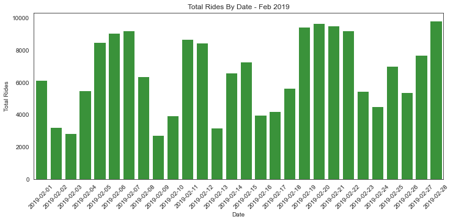

```python
# define plot label function
def xyt(xlabel, ylabel, title):
    '''takes three arguments, adds labels on the x- and y- axes and the plot title'''
    plt.xlabel(xlabel)
    plt.ylabel(ylabel)
    plt.title(title)

# plot the ride dates
order = df.date.value_counts().index.sort_values()
base_color = sns.color_palette()[2]
plt.figure(figsize=[12,5])
sns.countplot(data=df, x='date', color=base_color, order=order)
xyt('Date', 'Total Rides', 'Total Rides By Date - Feb 2019')
plt.xticks(rotation=45);
```

- Ridership appears to fluctuate. Let's take a look at ridership by day of week to see if there is an identifiable pattern:

### Which Days of the Week Are Most Popular for Rides?

```python
# create day of week (dow) column
df['dow'] = df['start_time'].dt.day_name()
df.head()
```

|  | duration_sec | start_time | end_time | start_station_id | start_station_name | start_station_latitude | start_station_longitude | end_station_id | end_station_name | end_station_latitude | end_station_longitude | bike_id | user_type | member_birth_year | member_gender | bike_share_for_all_trip | date | dow |
| --- | --- | --- | --- | --- | --- | --- | --- | --- | --- | --- | --- | --- | --- | --- | --- | --- | --- | --- |
| 0 | 52185 | 2019-02-28 17:32:10.145 | 2019-03-01 08:01:55.975 | 21 | Montgomery St BART Station (Market St at 2nd St) | 37.789625 | -122.400811 | 13 | Commercial St at Montgomery St | 37.794231 | -122.402923 | 4902 | Customer | 1984 | Male | No | 2019-02-28 | Thursday |
| 1 | 42521 | 2019-02-28 18:53:21.789 | 2019-03-01 06:42:03.056 | 23 | The Embarcadero at Steuart St | 37.791464 | -122.391034 | 81 | Berry St at 4th St | 37.775880 | -122.393170 | 2535 | Customer | 1984 | Not Given | No | 2019-02-28 | Thursday |
| 2 | 61854 | 2019-02-28 12:13:13.218 | 2019-03-01 05:24:08.146 | 86 | Market St at Dolores St | 37.769305 | -122.426826 | 3 | Powell St BART Station (Market St at 4th St) | 37.786375 | -122.404904 | 5905 | Customer | 1972 | Male | No | 2019-02-28 | Thursday |
| 3 | 36490 | 2019-02-28 17:54:26.010 | 2019-03-01 04:02:36.842 | 375 | Grove St at Masonic Ave | 37.774836 | -122.446546 | 70 | Central Ave at Fell St | 37.773311 | -122.444293 | 6638 | Subscriber | 1989 | Other | No | 2019-02-28 | Thursday |
| 4 | 1585 | 2019-02-28 23:54:18.549 | 2019-03-01 00:20:44.074 | 7 | Frank H Ogawa Plaza | 37.804562 | -122.271738 | 222 | 10th Ave at E 15th St | 37.792714 | -122.248780 | 4898 | Subscriber | 1974 | Male | Yes | 2019-02-28 | Thursday |

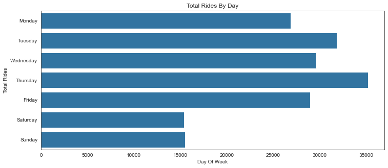

```python
# set base color
base_color = sns.color_palette()[0]

# set day of week order
order = ['Monday', 'Tuesday', 'Wednesday', 'Thursday', 'Friday', 'Saturday', 'Sunday']

# Use the `color` argument
plt.figure(figsize=[12,5])
sns.countplot(data=df, y='dow', color=base_color, order=order)
xyt('Day Of Week', 'Total Rides', 'Total Rides By Day');
```

- Weekdays are nearly twice as popular as weekends. This makes sense if people are using bikes to commute to work! Let's see how weekday versus weekend related to ridership:

```python
weekday = []
days = ['Saturday', 'Sunday']

# create weekday column 1 = yes, 0 = no
for row in df.dow:
    if row not in days:
        weekday.append('Weekday')
    else:
        weekday.append('Weekend')

df['weekday'] = weekday
df['weekday'] = df['weekday'].astype('category')
```

```python
df.weekday.value_counts()
```

```
Weekday    152484
Weekend     30928
Name: weekday, dtype: int64
```

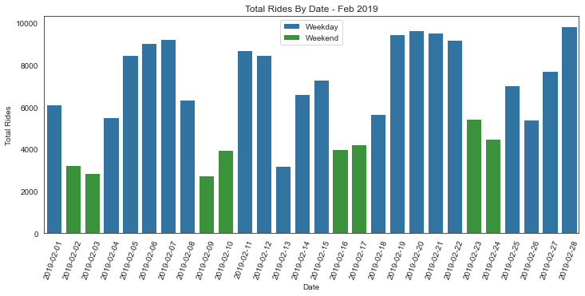

```python
# plot the ride dates
order = df.date.value_counts().index.sort_values()
base_color = sns.color_palette()[0]
plt.figure(figsize=[12,5])
sns.countplot(data=df, x='date', color=base_color, order=order, hue='weekday', palette=['C0', 'C2'], dodge=False)
xyt('Date', 'Total Rides', 'Total Rides By Date - Feb 2019')
plt.xticks(rotation=70)
plt.legend(loc='upper center');
```

- Weekends are obviously less popular than weekdays for bike rentals, with the exception of February 13th. Taking a look at the weather that date, it appears that it rained all day! Source: [timeanddate.com](https://www.timeanddate.com/weather/usa/san-francisco/historic?month=2&year=2019)

Now let's take a look at age distribution amongst riders. In order to do this, I am going to create a new column named `member_age`

### How is Age Distributed Amongst Riders?

```python
# create age column
# store current year
current_year = date.today().year

#create age column
df['member_age'] = current_year - df['member_birth_year']
df.info()
```

```
<class 'pandas.core.frame.DataFrame'>
RangeIndex: 183412 entries, 0 to 183411
Data columns (total 20 columns):
 #   Column                   Non-Null Count   Dtype
---  ------                   --------------   -----
 0   duration_sec             183412 non-null  int64
 1   start_time               183412 non-null  datetime64[ns]
 2   end_time                 183412 non-null  datetime64[ns]
 3   start_station_id         183412 non-null  int64
 4   start_station_name       183215 non-null  object
 5   start_station_latitude   183412 non-null  float64
 6   start_station_longitude  183412 non-null  float64
 7   end_station_id           183412 non-null  int64
 8   end_station_name         183215 non-null  object
 9   end_station_latitude     183412 non-null  float64
 10  end_station_longitude    183412 non-null  float64
 11  bike_id                  183412 non-null  int64
 12  user_type                183412 non-null  object
 13  member_birth_year        183412 non-null  int64
 14  member_gender            183412 non-null  object
 15  bike_share_for_all_trip  183412 non-null  object
 16  date                     183412 non-null  period[D]
 17  dow                      183412 non-null  object
 18  weekday                  183412 non-null  category
 19  member_age               183412 non-null  int64
dtypes: category(1), datetime64[ns](2), float64(4), int64(6), object(6), period[D](1)
memory usage: 26.8+ MB
```

[figure not shown]

```python
df.member_age.hist()
xyt('Age', 'Count', 'Age Distribution of Riders');
```

- There are certainly some outliers as I highly doubt there are riders over the age of 100. Let's take a further look.

```python
df.member_age.describe()
```

```
count    183412.000000
mean         37.182322
std          10.111453
min          21.000000
25%          30.000000
50%          35.000000
75%          42.000000
max         144.000000
Name: member_age, dtype: float64
```

- A 144 year old would be a record. Let's look at that observation.

```python
df.query("member_age == 144").member_birth_year
```

```
27370    1878
Name: member_birth_year, dtype: int64
```

- Looks like member_birth_year is listed as 1878 - I think we can safely assume that's a typo and update the observation:

```python
df.loc[df.member_birth_year == 1878, 'member_birth_year'] = 1978
df.query("member_age == 144")
```

|  | duration_sec | start_time | end_time | start_station_id | start_station_name | start_station_latitude | start_station_longitude | end_station_id | end_station_name | end_station_latitude | end_station_longitude | bike_id | user_type | member_birth_year | member_gender | bike_share_for_all_trip | date | dow | weekday | member_age |
| --- | --- | --- | --- | --- | --- | --- | --- | --- | --- | --- | --- | --- | --- | --- | --- | --- | --- | --- | --- | --- |
| 27370 | 1474 | 2019-02-25 09:28:42.161 | 2019-02-25 09:53:17.068 | 15 | San Francisco Ferry Building (Harry Bridges Pl... | 37.795392 | -122.394203 | 386 | 24th St at Bartlett St | 37.752105 | -122.419724 | 6436 | Customer | 1978 | Female | No | 2019-02-25 | Monday | Weekday | 144 |

```python
# view member_birth_years before 1950:
df.query("member_birth_year < 1950").member_birth_year.value_counts()
```

```
1947    139
1945    109
1949    102
1931     91
1900     55
1948     53
1943     32
1942     22
1933     20
1946     19
1939     11
1902     11
1941      9
1901      6
1920      3
1934      3
1938      3
1944      2
1928      2
1930      1
1910      1
1927      1
Name: member_birth_year, dtype: int64
```

- It's likely that anything before 1920 is a typo, but for the purpose of this analysis I am going to replace all ages over 80 with None

```python
df.loc[df.member_birth_year < 1942, 'member_birth_year'] = None
```

```python
# recalculate member_age column
df['member_age'] = current_year - df['member_birth_year']
df.info()
```

```
<class 'pandas.core.frame.DataFrame'>
RangeIndex: 183412 entries, 0 to 183411
Data columns (total 20 columns):
 #   Column                   Non-Null Count   Dtype
---  ------                   --------------   -----
 0   duration_sec             183412 non-null  int64
 1   start_time               183412 non-null  datetime64[ns]
 2   end_time                 183412 non-null  datetime64[ns]
 3   start_station_id         183412 non-null  int64
 4   start_station_name       183215 non-null  object
 5   start_station_latitude   183412 non-null  float64
 6   start_station_longitude  183412 non-null  float64
 7   end_station_id           183412 non-null  int64
 8   end_station_name         183215 non-null  object
 9   end_station_latitude     183412 non-null  float64
 10  end_station_longitude    183412 non-null  float64
 11  bike_id                  183412 non-null  int64
 12  user_type                183412 non-null  object
 13  member_birth_year        183195 non-null  float64
 14  member_gender            183412 non-null  object
 15  bike_share_for_all_trip  183412 non-null  object
 16  date                     183412 non-null  period[D]
 17  dow                      183412 non-null  object
 18  weekday                  183412 non-null  category
 19  member_age               183195 non-null  float64
dtypes: category(1), datetime64[ns](2), float64(6), int64(4), object(6), period[D](1)
memory usage: 26.8+ MB
```

```python
# view member_age summary statistics
df.member_age.describe()
```

```
count    183195.000000
mean         37.106995
std           9.863742
min          21.000000
25%          30.000000
50%          35.000000
75%          42.000000
max          80.000000
Name: member_age, dtype: float64
```

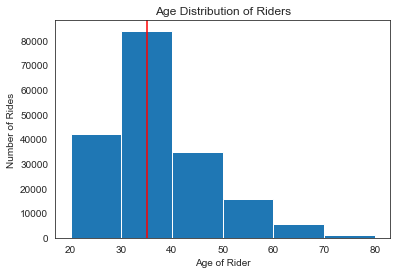

```python
bins = np.arange(20, df.member_age.max() + 5, 10)
plt.hist(data= df, x= 'member_age', bins=bins)
xyt('Age of Rider', 'Number of Rides', 'Age Distribution of Riders')
plt.axvline(x=df.member_age.median(), color='red'); #draw median line
```

- Since the dataset does not include unique member IDs, this distribution represents the member age of each ride, and not the distribution of ages amongst riders.

### What is the Distribution of Distance per Rides?

Next I'd like to take a look at the distribution of distances across all rides. To do this, I'll create a column in the dataframe which calculates the distance from the starting latitude/longitude to the ending latitude longitude using the [Haversein formula](https://en.wikipedia.org/wiki/Haversine_formula).

```python
# haversine function to calculate distance in km between two points
# credit https://stackoverflow.com/questions/29545704/fast-haversine-approximation-python-pandas/29546836#29546836
def haversine_np(lon1, lat1, lon2, lat2):
    """
    Calculate the great circle distance between two points
    on the earth (specified in decimal degrees)

    All args must be of equal length.

    """
    lon1, lat1, lon2, lat2 = map(np.radians, [lon1, lat1, lon2, lat2])

    dlon = lon2 - lon1
    dlat = lat2 - lat1

    a = np.sin(dlat/2.0)**2 + np.cos(lat1) * np.cos(lat2) * np.sin(dlon/2.0)**2

    c = 2 * np.arcsin(np.sqrt(a))
    km = 6367 * c
    return km
```

```python
# loop through the dataframe creating the distance_km column
for row in df:
    start_lat = df.start_station_latitude
    end_lat = df.end_station_latitude
    start_lon = df.start_station_longitude
    end_lon = df.end_station_longitude
    df['distance_km'] = haversine_np(start_lon, start_lat, end_lon, end_lat)
```

```python
df.distance_km.describe()
```

```
count    183412.000000
mean          1.689598
std           1.096900
min           0.000000
25%           0.910383
50%           1.429839
75%           2.224289
max          69.425625
Name: distance_km, dtype: float64
```

- Let's take a look to see if this max value is an outlier:

```python
df.query("distance_km > 4").bike_id.count()
```

```
7031
```

- There are quite a few large distances. I'm going to plot histograms side by side to getter a better sense of the distribution:

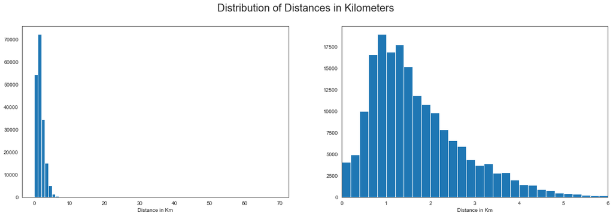

```python
# Define the figure size
plt.figure(figsize = [20, 6])

# full data on left
plt.subplot(1, 2, 1)
bin_edges = np.arange(0, df.distance_km.max()+0.1, 1)
plt.hist(data=df, x='distance_km', bins = bin_edges)
plt.xlabel('Distance in Km')
plt.suptitle('Distribution of Distances in Kilometers', fontsize=20)

# bulk of data on the right
plt.subplot(1, 2, 2)
bin_edges = np.arange(0, df.distance_km.max()+0.2, 0.2)
plt.hist(data=df, x='distance_km', bins = bin_edges)
plt.xlim(0, 6)
plt.xlabel('Distance in Km');
```

- We can observe from the above that most of the rides are between half-a-kilometer and two kilometers in distance, with a mean of 1.68 and a median of 1.42

Now let's see distribution of ride duration:

```python
df.duration_sec.describe()
```

```
count    183412.000000
mean        726.078435
std        1794.389780
min          61.000000
25%         325.000000
50%         514.000000
75%         796.000000
max       85444.000000
Name: duration_sec, dtype: float64
```

Duration in seconds makes sense for the dataframe, but provides an unwieldy (and opaque) range. Let's look at duration in minutes:

```python
# convert duration_sec column to minutes
df['duration_min'] = round(df.duration_sec / 60).astype(int)
df.duration_min.describe()
```

```
count    183412.000000
mean         12.101340
std          29.908512
min           1.000000
25%           5.000000
50%           9.000000
75%          13.000000
max        1424.000000
Name: duration_min, dtype: float64
```

This data makes a lot more sense. Here we see most rides are 15 minutes or less, with half the rides 9 minutes or less. We can see that the mean ride time of 12 minutes is affected by some outliers, as 75% of the rides are roughly 13 minutes or less. Let's take a look at the distribution of ride durations less than 1 hour:

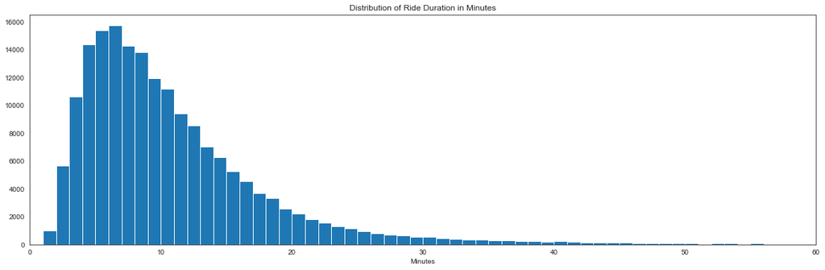

```python
# plot the data
plt.figure(figsize = [20, 6])
bin_edges = np.arange(0, df.duration_min.max()+1, 1)
plt.hist(df.duration_min, bins = bin_edges)
plt.xlim(0, 60)
plt.xlabel('Minutes')
plt.title("Distribution of Ride Duration in Minutes");
```

### What is the breakdown of Rides by Gender?

Let's take a look at the distribution of rides by gender:

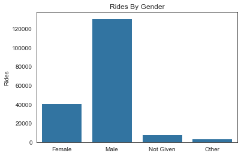

```python
gender_ct = df.groupby('member_gender')['bike_id'].count()
base_color = sns.color_palette()[0]
sns.barplot(x=gender_ct.index.values, y=gender_ct, color = base_color)
plt.ylabel('Rides')
plt.title('Rides By Gender');
```

• The bike service is far more popular overall amongst males. Let's look at how this breaks down as far as percentage of rides by gender:

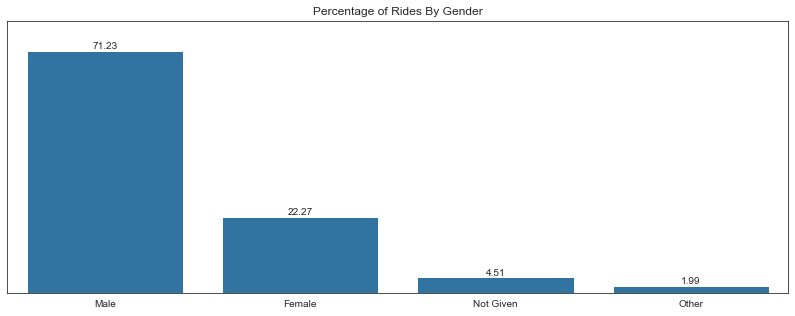

```python
gender_pct = df.member_gender.value_counts(normalize=True)
base_color = sns.color_palette()[0]
plt.figure(figsize=[14, 5])
ax = sns.barplot(x=gender_pct.index.values, y=round(gender_pct * 100, 2), color = base_color)
ax.bar_label(ax.containers[0])
plt.yticks([0, 80], [])
plt.ylabel(None)
plt.title('Percentage of Rides By Gender');
```

- Males account for just over 71% of all rides

### Which User Type is More Popular, Subscriber or Customer?

There are two types of users: Subscribers (members) and Customers (casual riders)

```python
mem_type = df.user_type.value_counts(normalize=True)
```

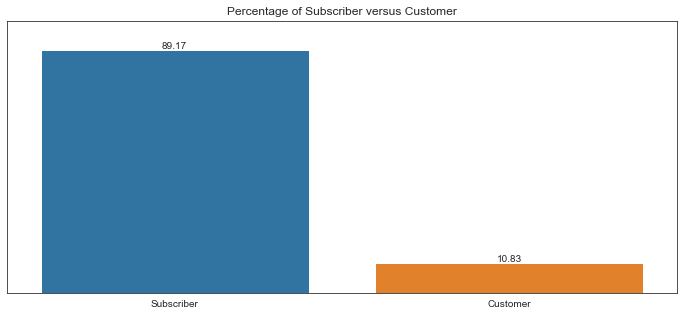

```python
plt.figure(figsize=[12,5])
ax = sns.barplot(x=mem_type.index.values, y=round(mem_type * 100, 2))
ax.bar_label(ax.containers[0])
plt.yticks([0,100], [])
plt.ylabel(None)
plt.title("Percentage of Subscriber versus Customer");
```

- Subscribers dramatically outweigh customers

### Which Stations are Most Popular?

Lastly, let's take a look at the most popular stations.

```python
df.start_station_id.nunique()
```

```
329
```

- There are records for 329 stations in the dataset

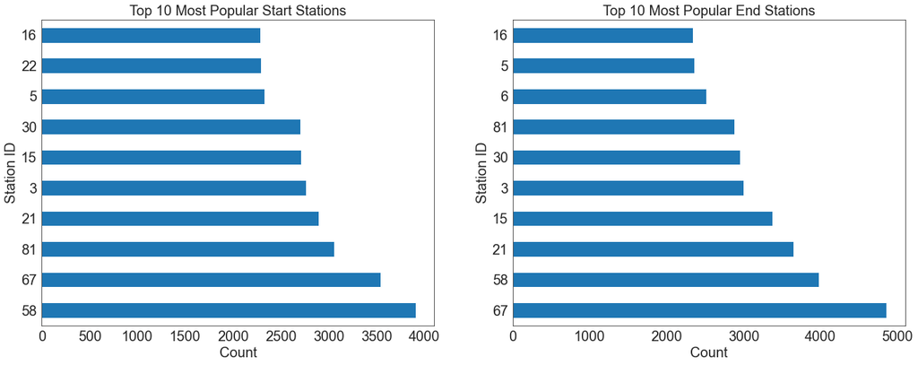

```python
plt.figure(figsize=[22,8])

def xyt_font(x, y, title):
    '''takes three arguments, returns x- y- axes labels, and plot title in font size 20
    and y-ticks in fontsize 20'''
    plt.xlabel(x, fontsize=20)
    plt.ylabel(y, fontsize=20)
    plt.yticks(fontsize=20)
    plt.xticks(fontsize=20)
    plt.title(title, fontsize=20)

# Top 10 Start Stations on left
plt.subplot(1, 2, 1)
df.start_station_id.value_counts()[:10].plot(kind='barh')
xyt_font('Count', 'Station ID', 'Top 10 Most Popular Start Stations')

# Top 10 End Stations on the right
plt.subplot(1, 2, 2)
df.end_station_id.value_counts()[:10].plot(kind='barh')
xyt_font('Count', 'Station ID', 'Top 10 Most Popular End Stations');
```

```python
df[['start_station_id', 'start_station_name']].value_counts()[:10]
```

```
start_station_id  start_station_name
58                Market St at 10th St                                         3904
67                San Francisco Caltrain Station 2  (Townsend St at 4th St)    3544
81                Berry St at 4th St                                           3052
21                Montgomery St BART Station (Market St at 2nd St)             2895
3                 Powell St BART Station (Market St at 4th St)                 2760
15                San Francisco Ferry Building (Harry Bridges Plaza)           2710
30                San Francisco Caltrain (Townsend St at 4th St)               2703
5                 Powell St BART Station (Market St at 5th St)                 2327
22                Howard St at Beale St                                        2293
16                Steuart St at Market St                                      2283
dtype: int64
```

```python
df[['end_station_id', 'end_station_name']].value_counts()[:10]
```

```
end_station_id  end_station_name
67              San Francisco Caltrain Station 2  (Townsend St at 4th St)    4857
58              Market St at 10th St                                         3973
21              Montgomery St BART Station (Market St at 2nd St)             3647
15              San Francisco Ferry Building (Harry Bridges Plaza)           3368
3               Powell St BART Station (Market St at 4th St)                 2997
30              San Francisco Caltrain (Townsend St at 4th St)               2947
81              Berry St at 4th St                                           2872
6               The Embarcadero at Sansome St                                2512
5               Powell St BART Station (Market St at 5th St)                 2353
16              Steuart St at Market St                                      2338
dtype: int64
```

- We can see that most of the top 10 overlap, with the exception of two stations. This makes sense that riders would use the bikes coming and going.

> **Rubric Tip**: Visualizations should depict the data appropriately so that the plots are easily interpretable. You should choose an appropriate plot type, data encodings, and formatting as needed. The formatting may include setting/adding the title, labels, legend, and comments. Also, do not overplot or incorrectly plot ordinal data.

### Discuss the distribution(s) of your variable(s) of interest. Were there any unusual points? Did you need to perform any transformations?

> From the univariate exploration I observe the following:
> - The average rider age is 37; half of all riders are between 21-35
> - 75% of all rides are 2.2 km in distance or less
> - 75% of all rides are 13 minutes in duration or less
> - 71% of all riders are male
> - 89% of all rides are by Subscribers
> - Weekdays are more popular for riders than weekends

## Bivariate Exploration

> In this section, investigate relationships between pairs of variables in your data. Make sure the variables that you cover here have been introduced in some fashion in the previous section (univariate exploration).

### What is the Average Distance and Duration of Rides by User Type?

First let's take a look at the average distance and duration of trips by user type:

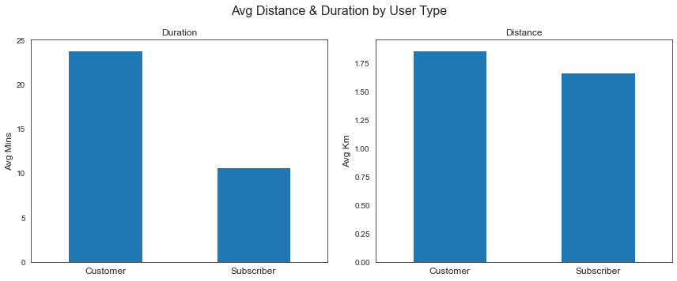

```python
plt.figure(figsize=[12,5])

def xyt_12(x, y, title):
    '''takes three arguments, plots x-axis label, y-axis label in 12pt font, title in 12pt
    font, xticks in 12pt font'''
    plt.xlabel(x)
    plt.ylabel(y, fontsize=12)
    plt.title(title, fontsize=12)
    plt.xticks(rotation=0, fontsize=12)

# plot the duration on the left
plt.subplot(1,2,1)
df.groupby('user_type').duration_min.mean().plot(kind='bar')
xyt_12(None, 'Avg Mins', 'Duration')

# plot distance on the right
plt.subplot(1,2,2)
df.groupby('user_type').distance_km.mean().plot(kind='bar')
xyt_12(None, 'Avg Km', 'Distance')

plt.suptitle("Avg Distance & Duration by User Type", fontsize=16)
plt.tight_layout(w_pad=2);
```

- Customers average longer durations and distances than subscribers, although the difference in distance is less pronounced than duration. This could be attributed to customers riding more casually than subscribers. Subscribers are regular users who likely commute to work or school, adhere to tighter schedules, and are more familiar with their routes, and thus take less time to travel equivalent distances as customers.

```python
df.groupby('user_type')['distance_km'].mean()
```

```
user_type
Customer      1.866033
Subscriber    1.668163
Name: distance_km, dtype: float64
```

### What is the Average Distance and Duration of Rides by Gender and User Type?

Let's take a look at the average duration and distance of trips by gender:

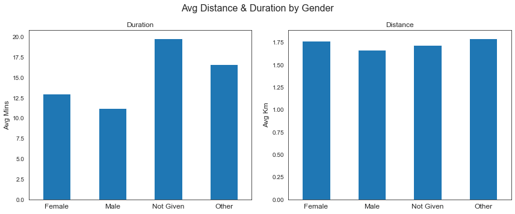

```python
plt.figure(figsize=[12,5])

# plot the duration on the left
plt.subplot(1,2,1)
df.groupby('member_gender').duration_min.mean().plot(kind='bar')
xyt_12(None, 'Avg Mins', 'Duration')

# plot distance on the right
plt.subplot(1,2,2)
df.groupby('member_gender').distance_km.mean().plot(kind='bar')
xyt_12(None, 'Avg Km', 'Distance')

plt.suptitle("Avg Distance & Duration by Gender", fontsize=16)
plt.tight_layout(w_pad=2);
```

- The difference is not particularly pronounced, although we can observe that females tend to ride longer and farther than males, and the longest trips are by people who did not provide a gender specification (either "Not Given" or "Other"). We know that casual riders (Customers) are more likely to take longer trips, let's take a look at the distribution of User Type by Gender:

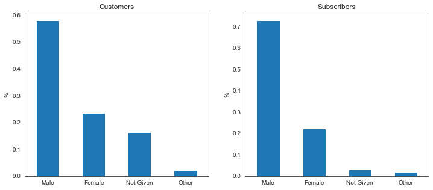

```python
plt.figure(figsize=[12,5])

# customer data on left
plt.subplot(1,2,1)
df.loc[df['user_type'] == 'Customer']['member_gender'].value_counts(normalize=True).plot(kind='bar')
plt.ylabel('%')
plt.title('Customers')
plt.xticks(rotation=0)

# subscriber data on right
plt.subplot(1,2,2)
df.loc[df['user_type'] == 'Subscriber']['member_gender'].value_counts(normalize=True).plot(kind='bar')
plt.ylabel('%')
plt.title('Subscribers')
plt.xticks(rotation=0);
```

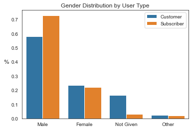

```python
gen_dist = df.groupby('user_type')['member_gender'].value_counts(normalize=True)
gen_dist = gen_dist.reset_index(name='pct')
sns.barplot(data = gen_dist, x='member_gender', y='pct', hue='user_type')
plt.ylabel('%', rotation=0, labelpad=10, fontsize=12)
plt.xlabel(None)
plt.legend(labels=None)
plt.title("Gender Distribution by User Type");
```

- Customers were less likely to provide their gender (Not Given) than subscribers.

### What is the Average Distance and Duration of Rides by Day of the Week?

Now let's take a look at average duration and distance by day of the week

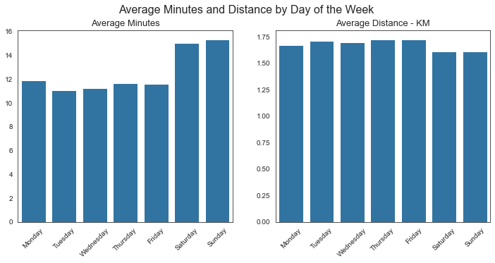

```python
order = ['Monday', 'Tuesday', 'Wednesday', 'Thursday', 'Friday', 'Saturday', 'Sunday']
plt.figure(figsize=[12,5])

# plot the avg duration on the left
plt.subplot(1,2,1)
top_color = sns.color_palette()[0]
dur_day = df.groupby('dow')['duration_min'].mean().reset_index(name='avg_mins')
sns.barplot(data=dur_day, x='dow', y='avg_mins', color=top_color, order=order)
plt.xticks(rotation=45)
plt.xlabel(None)
plt.ylabel(None)
plt.title('Average Minutes', fontsize=13)

#plot the avg distance on the right
plt.subplot(1,2,2)
dis_day = df.groupby('dow')['distance_km'].mean().reset_index(name='avg_dist')
sns.barplot(data=dis_day, x='dow', y='avg_dist', color=top_color, order=order)
plt.xticks(rotation=45)
plt.xlabel(None)
plt.ylabel(None)
plt.title('Average Distance - KM', fontsize=13)

plt.suptitle('Average Minutes and Distance by Day of the Week', fontsize=16);
```

- We can see that although trips are shorter during the weekdays, on average they are actually longer in distance traveled. This makes sense if people are using the bikes during the week to commute to work or school and are therefore in a hurry, as oppposed to the weekends.

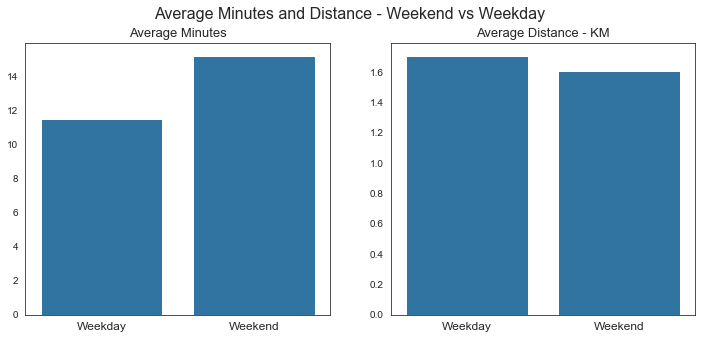

```python
# plot weekend versus weekday

plt.figure(figsize=[12,5])

# plot the avg duration on the left
plt.subplot(1,2,1)
color = sns.color_palette()[0]
dur_day = df.groupby('weekday')['duration_min'].mean().reset_index(name='avg_mins')
sns.barplot(data=dur_day, x='weekday', y='avg_mins', color=color)
plt.xticks(rotation=0, fontsize=12)
plt.xlabel(None)
plt.ylabel(None)
plt.title('Average Minutes', fontsize=13)

#plot the avg distance on the right
plt.subplot(1,2,2)
dis_day = df.groupby('weekday')['distance_km'].mean().reset_index(name='avg_dist')
sns.barplot(data=dis_day, x='weekday', y='avg_dist', color=color)
plt.xticks(rotation=0, fontsize=12)
plt.xlabel(None)
plt.ylabel(None)
plt.title('Average Distance - KM', fontsize=13)

plt.suptitle('Average Minutes and Distance - Weekend vs Weekday', fontsize=16);
```

## Multivariate Exploration

### How Does Distance and Duration Vary Amongst the Most Popular Stations from Weekdays to Weekend?

Let's take another look at the distribution of distance and duration on the weekends as opposed to the weekday using the top 10 most popular starting stations.

```python
pop_start_list = list(df.start_station_id.value_counts()[:10].index)
pop_end_list = list(df.end_station_id.value_counts()[:10].index)
```

```python
pop_start = df.loc[df['start_station_id'].isin(pop_start_list)].groupby(['start_station_id', 'weekday'])[['distance_km', 'duration_min']].mean().reset_index()
pop_end = df.loc[df['end_station_id'].isin(pop_end_list)].groupby(['end_station_id', 'weekday'])[['distance_km', 'duration_min']].mean().reset_index()
```

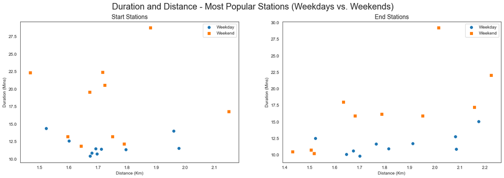

```python
# Define the figure size
plt.figure(figsize = [20, 6])

# full data on left
plt.subplot(1, 2, 1)

cat_markers = [['Weekday', 'o'],
               ['Weekend', 's']]

for cat, marker in cat_markers:
    start_cat = pop_start[pop_start['weekday'] == cat]
    plt.scatter(data = start_cat, x = 'distance_km', y = 'duration_min', marker = marker)
plt.legend(['Weekday','Weekend'])
plt.xlabel('Distance (Km)')
plt.ylabel('Duration (Mins)')
plt.title('Start Stations', fontsize=14)

# bulk of data on the right
plt.subplot(1, 2, 2)

for cat, marker in cat_markers:
    end_cat = pop_end[pop_end['weekday'] == cat]
    plt.scatter(data = end_cat, x = 'distance_km', y = 'duration_min', marker = marker)
plt.legend(['Weekday','Weekend'])
plt.xlabel('Distance (Km)')
plt.ylabel('Duration (Mins)')
plt.title('End Stations', fontsize=14)

plt.suptitle('Duration and Distance - Most Popular Stations (Weekdays vs. Weekends)', fontsize=20);
```

- It's clear by the above that comparable distances tend to take longer on the weekends than during the week. Let's now take a look at speed to see if we can get a clearer understand of the distribution amongst gender

### How Does Age Affect Speed By User Type and Weekday versus Weekend?

```python
# calculate speed as distance divided by time
df['speed'] = round(df.distance_km / df.duration_min, 2)

speed = df.groupby(['member_gender', 'weekday'])['speed'].mean()
```

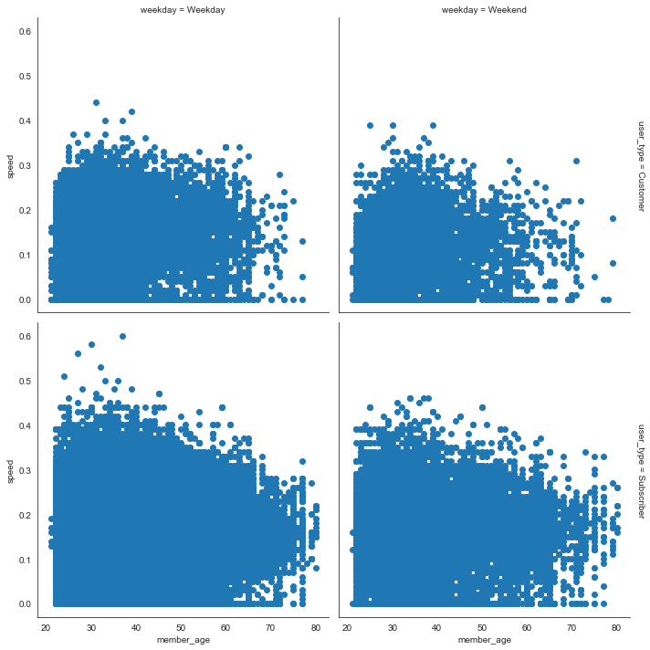

```python
g = sns.FacetGrid(data = df, col = 'weekday', row = 'user_type', height = 5,
                margin_titles = True)
g.map(plt.scatter, 'member_age', 'speed');
```

- We can see here that subscribers ride faster than customers, speed generally decreases with age, and both subscribers and customers ride slower on the weekends than on weekdays

Let's see how much faster riders ride during the week on average than on weekends

```python
avg_speed = df.groupby('weekday')['speed'].mean()
df.groupby('weekday')['speed'].mean()
```

```
weekday
Weekday    0.183564
Weekend    0.163108
Name: speed, dtype: float64
```

```python
def pct_diff(a, b):
    '''calculates the percentage difference between two variables'''
    diff = round(((a - b) / ((a + b) / 2)) * 100, 2)
    return diff
```

```python
day_spd = avg_speed[0]
end_spd = avg_speed[1]
pct_diff(day_spd, end_spd)
```

```
11.8
```

- Riders ride 11.8% faster during the week than on weekends

### What is the Age Distribution of Riders During the Week versus the Weekend?

Let's take a look at the age distribution of riders during the week as opposed to the weekend.

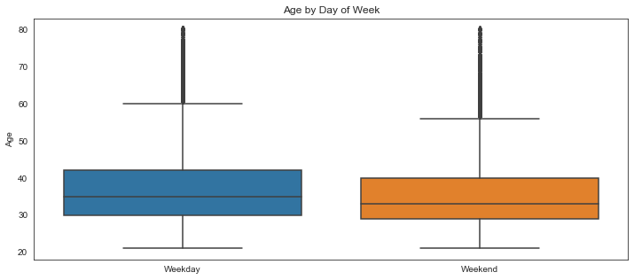

```python
plt.figure(figsize=[12,5])
sns.boxplot(data=df, x='weekday', y='member_age')
xyt('', 'Age', 'Age by Day of Week');
```

- We can see that weekends skew younger than weekdays, which makes sense as ridership seems to be related to commuting to work.

```python
df.groupby('weekday')['member_age'].describe()
```

| weekday | count | mean | std | min | 25% | 50% | 75% | max |
| --- | --- | --- | --- | --- | --- | --- | --- | --- |
| Weekday | 152297.0 | 37.349541 | 9.802206 | 21.0 | 30.0 | 35.0 | 42.0 | 80.0 |
| Weekend | 30898.0 | 35.911483 | 10.076824 | 21.0 | 29.0 | 33.0 | 40.0 | 80.0 |

### What is the Average Speed per Riders during the Week vs. Weekend by User Type?

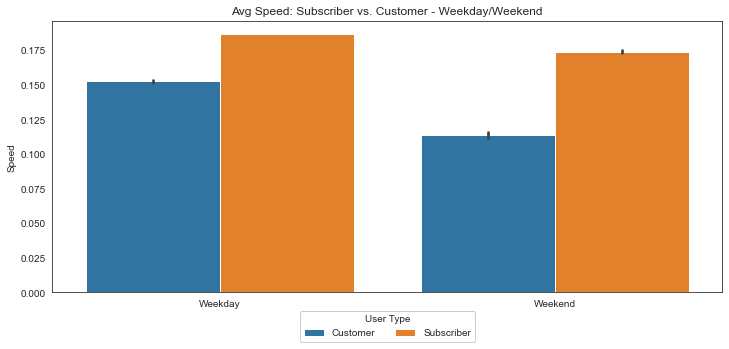

```python
plt.subplots(figsize=[12,5])
ax = sns.barplot(data = df, x = 'weekday', y = 'speed', hue = 'user_type')
ax.legend(loc = 'lower center', ncol = 2, framealpha = 1, title = 'User Type', bbox_to_anchor=(0.5, -0.2, 0., 0.5))
ax.set_xlabel('')
ax.set_ylabel('Speed')
ax.set_title('Avg Speed: Subscriber vs. Customer - Weekday/Weekend');
```

- Subscribers ride faster than customers, likely due to familiarity, and both groups ride faster during the week than on weekends.

### Talk about some of the relationships you observed in this part of the investigation. Were there features that strengthened each other in terms of looking at your feature(s) of interest?

> Subscribers ride faster than customers, speed generally decreases with age, and both subscribers and customers ride slower on the weekends than on weekdays.  
> Ridership skews older on the weekdays than weekends.  
> Distances tend to remain consistent between weekends and weekdays, but riders ride faster during the week.